# The Impact of Membership on Customer’s Purchase

```r
options(repos = c(CRAN = "https://cloud.r-project.org"))
```

## Project Summary

Our client, Harris Teeter, is a leading regional supermarket chain in the United States, and they are asking us to answer this one qustion : **Does the VIC (Very Important Customer) membership ensure more purchases from each customer?** They are trying to see if it is worth enforcing a new promotional measure of offering a one-month free VIC memberhip trial to all customers and trying to see the effectiveness of this marketing schema beforehand.

#### DAG Analysis

From the DAG analysis, the criteria are D(Membership Status), X(Confounders - as gender, salary, age and marital status), and Y (Purchased amount). We will determine the TE through this Z, free membership trial as the X is already preassigned to each customer, and shows an imbalance of data.

#### Methods Used

For assuring a RCT, we used **Block treatment assignment** with probability of treatment being 0.5. For causal inference, we used **Exact Matching, Propensity Score Matching** and **IPTW Matching** and examined the effect of each through t-tests(p-value analysis).

#### Results of Analysis

From **Exact Matching,** the TE was **$1,205.** From **Propensity Score Matching**, the TE was **$1,207.** Finally, from Inverse Probability of Treatment Weighting, the TE was $1,204. This shows a causal effect from D(Membership Status) -> Y(Customer Spendings) were over $1.2K for every method utilized.

## Data Simulation

The following is the data to be used.

**[Dataset Dictionary]**

- Customer ID: Primary Key for individual customers
- Membership: 1 = Enrolled in VIC membership, 0 = Not enrolled
- Gender: 1=Female, 0=Male
- Salary: Individual Annual Salary (in thousands. eg. 54.2 = $54.2K)
- Age: 18-72
- Marital Status: 1= Married, 0 = Single
- Purchased: Dollar amount of total purchases in year 2025.

**[DAG Dictionary]**

- Outcome(Y): Purchased
- Treatment(D): Membership
- Treatment Effect: Impact of having membership account on total purchased amount
- Potential Confounders(X): Gender, Salary, Age, Marital Status

Claude log: https://claude.ai/chat/f264f04b-dc36-451f-8fe1-d8d73ed4a0c0

## Exploratory Data Analysis

```r
url <- "https://raw.githubusercontent.com/jyubin0114/harris-teeter-membership-impact/refs/heads/main/harris_teeter_customer_data.csv"

data <- read.csv(url)

library(tidyverse)
library(skimr)
df <- data %>%
  mutate(
    Membership = factor(Membership, levels = c(0,1), labels = c("No", "Yes")),
    Gender = factor(Gender, levels = c(0,1), labels = c("Male", "Female")),
    Marital_Status = factor(Marital_Status, levels = c(0,1), labels = c("Single", "Married"))
  )
```

### Distribution of Key Variables

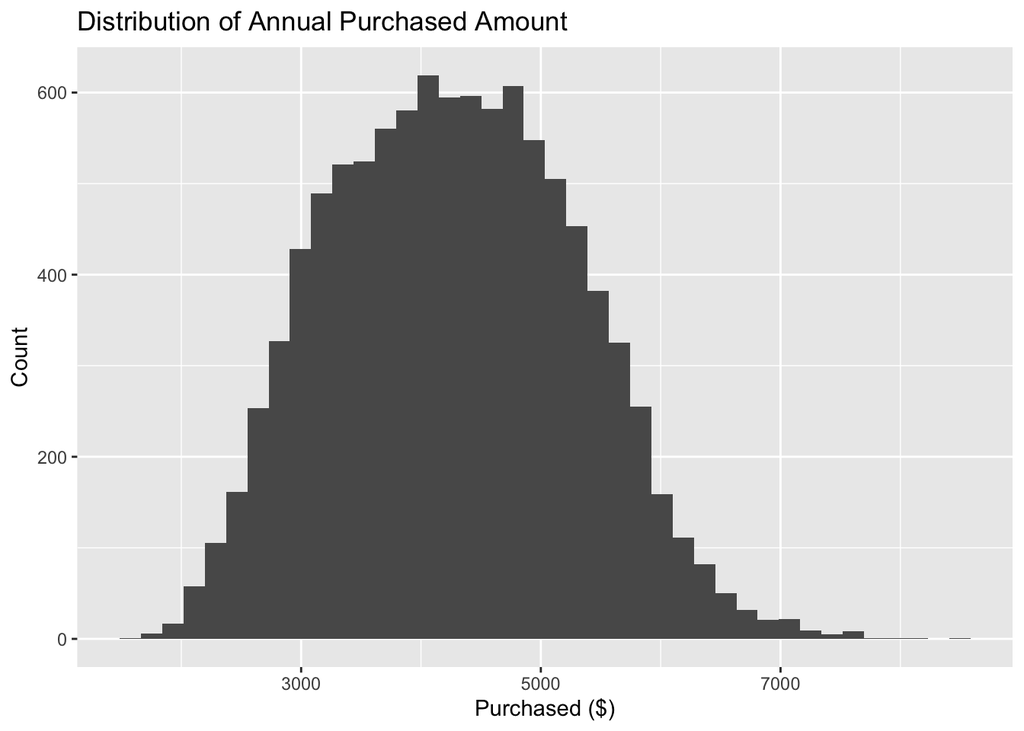

```r
ggplot(df, aes(x = Purchased)) +
  geom_histogram(bins = 40) +
  labs(title = "Distribution of Annual Purchased Amount",
       x = "Purchased ($)", y = "Count")
```

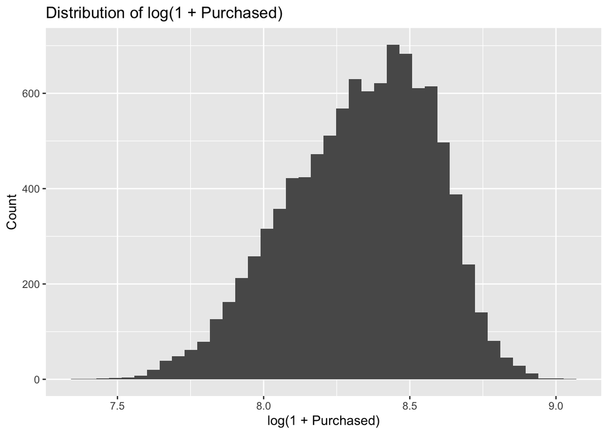

```r
ggplot(df, aes(x = log1p(Purchased))) +
  geom_histogram(bins = 40) +
  labs(title = "Distribution of log(1 + Purchased)",
       x = "log(1 + Purchased)", y = "Count")
```

Purchased is right-skewed; we also examine log(1 + Purchased) for clearer visualization of the bulk of the distribution.

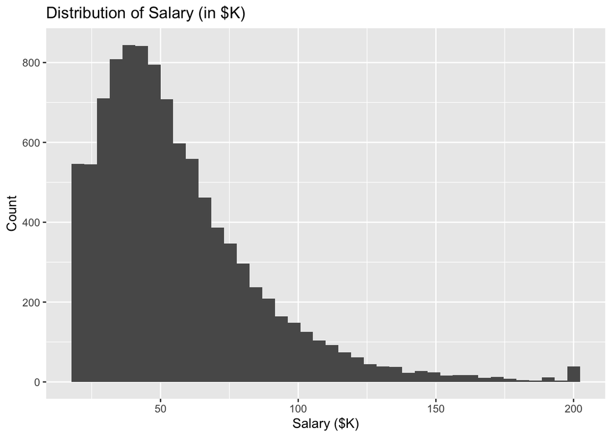

```r
ggplot(df, aes(x = Salary)) +
  geom_histogram(bins = 40) +
  labs(title = "Distribution of Salary (in $K)",
       x = "Salary ($K)", y = "Count")
```

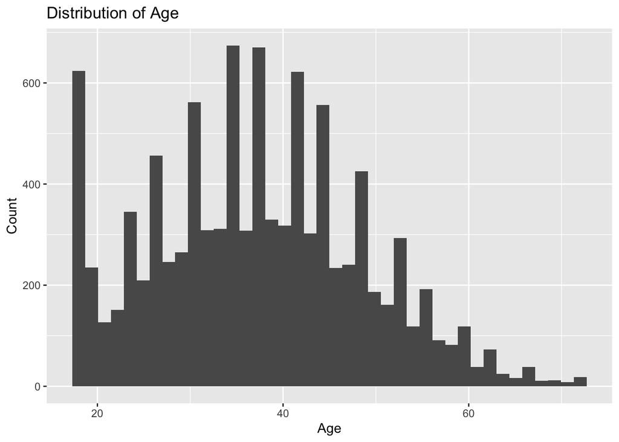

```r
ggplot(df, aes(x = Age)) +
  geom_histogram(bins = 40) +
  labs(title = "Distribution of Age",
       x = "Age", y = "Count")
```

Salary shows a similar right-skewed pattern, consistent with real-world income data, while age is concentrated around the mid-adult range.

### Descriptive Differences by Membership Status

```r
balance_tbl <- df %>%
  group_by(Membership) %>%
  summarise(
    n = n(),
    mean_salary = mean(Salary),
    mean_age = mean(Age),
    prop_female = mean(Gender == "Female"),
    prop_married = mean(Marital_Status == "Married"),
    mean_purchased = mean(Purchased)
  )

balance_tbl
```

```
# A tibble: 2 × 7
  Membership     n mean_salary mean_age prop_female prop_married mean_purchased
  <fct>      <int>       <dbl>    <dbl>       <dbl>        <dbl>          <dbl>
1 No          4786        53.1     36.5       0.481        0.369          3526.
2 Yes         5214        59.4     38.0       0.555        0.487          4954.
```

### Covariate Balance and Evidence of Selection Bias

```r
smd_cont <- function(x, d){
  x1 <- x[d == "Yes"]; x0 <- x[d == "No"]
  (mean(x1) - mean(x0)) / sqrt((var(x1) + var(x0)) / 2)
}

smd_bin <- function(x, d){
  x1 <- x[d == "Yes"]; x0 <- x[d == "No"]
  p1 <- mean(x1); p0 <- mean(x0)
  (p1 - p0) / sqrt((p1*(1-p1) + p0*(1-p0)) / 2)
}

smds <- tibble(
  variable = c("Salary", "Age", "Female", "Married"),
  smd = c(
    smd_cont(df$Salary, df$Membership),
    smd_cont(df$Age, df$Membership),
    smd_bin(df$Gender == "Female", df$Membership),
    smd_bin(df$Marital_Status == "Married", df$Membership)
  )
)

smds
```

```
# A tibble: 4 × 2
  variable   smd
  <chr>    <dbl>
1 Salary   0.216
2 Age      0.133
3 Female   0.148
4 Married  0.240
```

We assess covariate balance using standardized mean differences (SMD). As a rule of thumb, |SMD| > 0.1 indicates meaningful imbalance between the membership and non-membership groups.

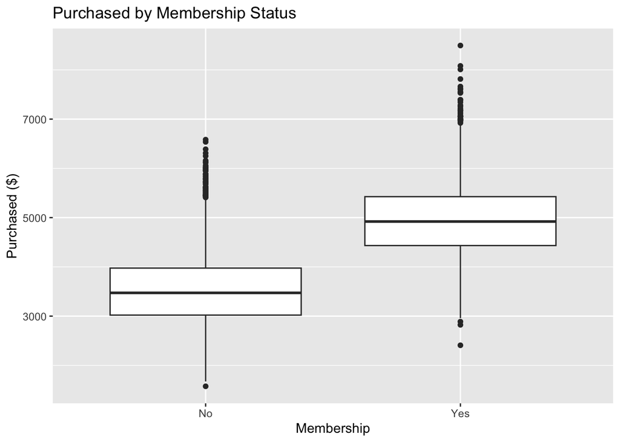

```r
ggplot(df, aes(x = Membership, y = Purchased)) +
  geom_boxplot() +
  labs(title = "Purchased by Membership Status",
       x = "Membership", y = "Purchased ($)")
```

The enrolled group appears to have higher raw annual purchases; however, this comparison is purely correlational. Given observed differences in salary and age, the naive gap may reflect selection bias rather than a causal membership effect.

### Summary

The exploratory analysis shows that customers who join the loyalty program are systematically different from those who do not. In particular, members tend to have higher income, are slightly older, and are more likely to be female and married. These characteristics are also strongly related to purchasing behavior. As a result, differences in observed spending between members and non-members should be interpreted with caution, as they may reflect customer selection rather than the effect of the loyalty program itself.

## Methodology (RCT)

### Non-technical description of the method

To study the causal effect of a membership-related marketing intervention, we implement the structure of a randomized controlled trial (RCT.) Because the observed dataset does not contain an actual randomized assignment, we simulate an experiment in which customers are randomly offered a 1-month free membership trial. This allows us to estimate the average causal effect of the offer using an intention-to-treat (ITT) framework.

```r
library(tidyverse)
library(tableone)
library(sandwich)
library(lmtest)
```

### Technical implementation

1. **Block construction using a pre-treatment covariate**

   To implement a blocked RCT, we stratify customers based on salary, a key pre-treatment covariate that strongly predicts both purchases and membership enrollment. Salary is divided into quartiles, and each customer is assigned to a salary block. Blocking ensures balance on this important covariate and improves the precision of treatment effect estimates.

```r
data <- data %>% mutate(Salary_q = ntile(Salary, 4), Block_id = paste0("Sal_q", Salary_q))

# Quick block sizes (informational)
block_sizes <- data %>% count(Block_id) %>% arrange(desc(n))
print(block_sizes)
```

```
  Block_id    n
1   Sal_q1 2500
2   Sal_q2 2500
3   Sal_q3 2500
4   Sal_q4 2500
```

2. **Block treatment assignment (randomization)**

   Within each salary block, we randomly assign the free membership trial offer `Free_trial_offer` with probability 0.5. This block treatment assignment ensures that randomization occurs within homogeneous strata while maintaining equal treatment probability across blocks.

```r
set.seed(202601)
data <- data %>% group_by(Block_id) %>%
  mutate(Free_trial_offer = rbinom(n(), 1, 0.5)) %>%
  ungroup()

# Check overall and by-block assignment rates
cat("Overall offer rate:", mean(data$Free_trial_offer), "\n")
```

```
Overall offer rate: 0.507
```

```r
print(data %>% group_by(Block_id) %>% summarize(n = n(), offer_rate = mean(Free_trial_offer)) %>% arrange(desc(n)))
```

```
# A tibble: 4 × 3
  Block_id     n offer_rate
  <chr>    <int>      <dbl>
1 Sal_q1    2500      0.499
2 Sal_q2    2500      0.506
3 Sal_q3    2500      0.504
4 Sal_q4    2500      0.518
```

3. **Balance check for the randomized assignment**

   As a sanity check, we examine the distribution of key pre-treatment covariates across treatment status. By construction, the randomized offer should be independent of pre-treatment characteristics.

```r
# means of key pre-treatment X by Z
cat("Mean salary by Z: \n")
```

```
Mean salary by Z:
```

```r
print(data %>% group_by(Free_trial_offer) %>% summarize(mean_salary = mean(Salary, na.rm=TRUE), n = n()))
```

```
# A tibble: 2 × 3
  Free_trial_offer mean_salary     n
             <int>       <dbl> <int>
1                0        55.8  4930
2                1        56.9  5070
```

4. **ITT estimation with block fixed effects**

   We estimate the treatment effect using an ITT specification. Purchases are regressed on the randomized offer indicator, controlling for block fixed effects to account for systematic differences across salary strata. Robust (HC1) standard errors are used.

```r
# Purchased ~ Z + block fixed effects
# Estimate ITT vis OLS controlling for block fixed effects with robust SE.
data$Block_factor <- factor(data$Block_id)
itt_model <- lm(Purchased ~ Free_trial_offer + Block_factor, data=data)
itt_se <- vcovHC(itt_model, type = "HC1")
cat("ITT estimate (Z -> Y):\n")
```

```
ITT estimate (Z -> Y):
```

```r
print(coeftest(itt_model, vcov. = itt_se))
```

```
t test of coefficients:

                   Estimate Std. Error  t value Pr(>|t|)
(Intercept)        3767.387     20.134 187.1149   <2e-16 ***
Free_trial_offer     11.710     18.227   0.6424   0.5206
Block_factorSal_q2  228.667     25.225   9.0651   <2e-16 ***
Block_factorSal_q3  539.199     25.250  21.3542   <2e-16 ***
Block_factorSal_q4 1219.989     26.292  46.4008   <2e-16 ***
---
Signif. codes:  0 '***' 0.001 '**' 0.01 '*' 0.05 '.' 0.1 ' ' 1
```

5. **First-stage regression (compliance check)**

   We also estimate a first-stage regression to assess how strongly the randomized offer translates into actual membership enrollment. This step diagnoses compliance in the experiment.

```r
# Effect Z --> D
# Check how strongly the offer induced membership.
fs_model <- lm(Membership ~ Free_trial_offer + Block_factor, data=data)
fs_se <- vcovHC(fs_model, type = "HC1")
cat("First-stage estimate (Z -> D):\n")
```

```
First-stage estimate (Z -> D):
```

```r
print(coeftest(fs_model, vcov. = fs_se))
```

```
t test of coefficients:

                    Estimate Std. Error t value  Pr(>|t|)
(Intercept)        0.4584855  0.0111392 41.1596 < 2.2e-16 ***
Free_trial_offer   0.0158543  0.0099228  1.5978    0.1101
Block_factorSal_q2 0.0098858  0.0141185  0.7002    0.4838
Block_factorSal_q3 0.0579239  0.0141242  4.1011 4.145e-05 ***
Block_factorSal_q4 0.1516956  0.0139292 10.8905 < 2.2e-16 ***
---
Signif. codes:  0 '***' 0.001 '**' 0.01 '*' 0.05 '.' 0.1 ' ' 1
```

### Justification and Assumptions

Salary is chosen as the blocking variable because it is a strong pre-treatment predictor of both purchases and membership. A blocked RCT ensures balance on this key covariate while remaining simple to implement. The analysis relies on the assumption that the randomized offer is independent of pre-treatment covariates and that there is no interference across units. The randomized offer is simulated for methodological illustration and is not used in subsequent matching analyses.

## Findings (RCT)

- **Blocking and randomization:** We stratified by salary quartiles and randomized a free_trial_offer within each block at 50% probability. Pre-treatment characteristics appear similar across offer groups. Block assignment rates (~0.499–0.518) are consistent with successful within-block randomization.
- **ITT result:** The ITT estimate is **$11.71 (SE = 18.23, p = 0.52)** — not statistically significant. This effect is economically small relative to average annual purchases and statistically insignificant. We cannot conclude the offer meaningfully increased purchases on average.
- **First-stage (compliance):** The offer increased membership probability by ~**1.6 percentage points (p = 0.11)**, which is not statistically significant, indicating weak take-up of the offer.

```r
results_summary <- data.frame(
  Metric = c("ITT Effect on Purchases", "First Stage Effect on Membership"),
  Estimate = c(coef(itt_model)["Free_trial_offer"],
               coef(fs_model)["Free_trial_offer"])
)
print(results_summary)
```

```
                            Metric    Estimate
1          ITT Effect on Purchases 11.70956389
2 First Stage Effect on Membership  0.01585428
```

- **Interpretation:** Non-significant ITT may reflect no true effect, limited power, or a weak offer-to-membership pathway. Given the weak first-stage, estimating the causal effect of membership (D→Y) via IV would be unreliable.
- **Recommendations:** (i) strengthen the offer design (e.g., immediate sign-up bonus), (ii) increase sample size or target higher-takeup subgroups, and (iii) combine matching-based observational adjustments (Exact, PSM, IPTW) with experimental insights for robust inference. Do not include the simulated `free_trial_offer` as a covariate in matching analyses.

## Methodology (Matching)

### Non-technical description of the method

Because membership enrollment is self-selected rather than randomized, naive comparisons suffer from selection bias. We therefore employ matching-based causal inference methods to construct comparable treated and control groups based on pre-treatment covariates. Matching aims to approximate the counterfactual outcomes by pairing members and non-members with similar characteristics. We implement Exact Matching, Propensity Score Matching, and Inverse Probability of Treatment Weighting (IPTW) to assess robustness.

### Technical implementation

```r
library(MatchIt)
library(marginaleffects) # for avg_comparision & avg_predictions
library(ggplot2)
library(cobalt)
library(gridExtra)
library(sandwich)
library(lmtest)
set.seed(202601)
```

#### Exact Matching

Exact Matching pairs treated and control units that have identical values for selected covariates. This approach eliminates bias from those covariates entirely but may discard many observations when covariates are continuous or high-dimensional. In our setting, we perform Exact Matching on Gender and Marital Status, which are discrete and economically meaningful pre-treatment variables.

```r
# Exact Matching on Gender and Marital Status
matches_exact <- matchit(
  Membership ~ Gender + Marital_Status, data=data, method = "exact"
)

# Print summary text to file
print(summary(matches_exact))
```

```
Call:
matchit(formula = Membership ~ Gender + Marital_Status, data = data,
    method = "exact")

Summary of Balance for All Data:
               Means Treated Means Control Std. Mean Diff. Var. Ratio eCDF Mean
Gender                0.5550        0.4812          0.1486          .    0.0738
Marital_Status        0.4868        0.3688          0.2360          .    0.1180
               eCDF Max
Gender           0.0738
Marital_Status   0.1180

Summary of Balance for Matched Data:
               Means Treated Means Control Std. Mean Diff. Var. Ratio eCDF Mean
Gender                0.5550        0.5550              -0          .         0
Marital_Status        0.4868        0.4868              -0          .         0
               eCDF Max Std. Pair Dist.
Gender                0               0
Marital_Status        0               0

Sample Sizes:
              Control Treated
All           4786.      5214
Matched (ESS) 4419.89    5214
Matched       4786.      5214
Unmatched        0.         0
Discarded        0.         0
```

```r
# Extract mathced dataset
matched_exact <- match.data(matches_exact)
```

ATE/ATT via Difference-in-Means and regression (with robust SE)

- On matched sample run difference-in-means and weighted regression.

```r
# Difference in means (treated - control) on matched sample
mean_treated <- mean(matched_exact$Purchased[matched_exact$Membership == 1], na.rm = TRUE)
mean_control <- mean(matched_exact$Purchased[matched_exact$Membership == 0], na.rm = TRUE)
dim_estimate <- mean_treated - mean_control

cat("Exact Matching: Difference-in-means (Treated - Control):", dim_estimate, "\n")
```

```
Exact Matching: Difference-in-means (Treated - Control): 1427.705
```

```r
# Weighted regression (include covariates for precision)
# Use 'weights' column generated by MatchIt
model_exact <- lm(Purchased ~ Membership + Age + Salary + Gender + Marital_Status,
                  data = matched_exact, weights = weights)

# Robust SE
se_exact <- vcovHC(model_exact, type = "HC1")
coefs_exact <- coeftest(model_exact, vcov. = se_exact)
print(coefs_exact)
```

```
t test of coefficients:

                 Estimate Std. Error t value  Pr(>|t|)
(Intercept)    1999.25520   16.58548 120.543 < 2.2e-16 ***
Membership     1205.26512    8.22922 146.462 < 2.2e-16 ***
Age               7.99333    0.35651  22.421 < 2.2e-16 ***
Salary           14.96200    0.13829 108.195 < 2.2e-16 ***
Gender          302.28325    8.14581  37.109 < 2.2e-16 ***
Marital_Status  798.82140    8.18994  97.537 < 2.2e-16 ***
---
Signif. codes:  0 '***' 0.001 '**' 0.01 '*' 0.05 '.' 0.1 ' ' 1
```

#### Propensity Score Matching

To address the problems of Exact Matching, we implement Propensity Score Matching, which summarizes multiple covariates into a single scalar, the probability of receiving treatment conditional on covariates. We estimate propensity scores using a logistic regression of membership on pre-treatment covariates and then match treated and control units with similar propensity scores using nearest-neighbor matching.

```r
# Propensity Score Matching using Nearest Neighbor
matches_psm <- matchit(
  Membership ~ Age + Salary + Gender + Marital_Status,
  data = data,
  method = "nearest",
  distance = "logit",
  estimand = "ATT"
)
# Summary
psm_sum <- summary(matches_psm)
print(psm_sum)
```

```
Call:
matchit(formula = Membership ~ Age + Salary + Gender + Marital_Status,
    data = data, method = "nearest", distance = "logit", estimand = "ATT")

Summary of Balance for All Data:
               Means Treated Means Control Std. Mean Diff. Var. Ratio eCDF Mean
distance              0.5384        0.5029          0.3789     1.0706    0.1096
Age                  37.9935       36.4812          0.1302     1.1024    0.0275
Salary               59.4006       53.0627          0.2054     1.2272    0.0488
Gender                0.5550        0.4812          0.1486          .    0.0738
Marital_Status        0.4868        0.3688          0.2360          .    0.1180
               eCDF Max
distance         0.1616
Age              0.0738
Salary           0.1305
Gender           0.0738
Marital_Status   0.1180

Summary of Balance for Matched Data:
               Means Treated Means Control Std. Mean Diff. Var. Ratio eCDF Mean
distance              0.5528        0.5029          0.5328     0.8522    0.1532
Age                  38.7509       36.4812          0.1954     1.0940    0.0413
Salary               61.4902       53.0627          0.2732     1.2511    0.0650
Gender                0.5972        0.4812          0.2333          .    0.1160
Marital_Status        0.5303        0.3688          0.3231          .    0.1615
               eCDF Max Std. Pair Dist.
distance         0.2194          0.5328
Age              0.0961          1.0625
Salary           0.1621          0.8383
Gender           0.1160          0.9094
Marital_Status   0.1615          0.6250

Sample Sizes:
          Control Treated
All          4786    5214
Matched      4786    4786
Unmatched       0     428
Discarded       0       0
```

```r
# Extract matched data
matched_psm <- match.data(matches_psm)
```

Print standardized mean differences and estimate ATT via avg_comparisons on matched sample.

```r
# Print SMD table
cat("PSM: Standardized Mean Differences (before & after):\n")
```

```
PSM: Standardized Mean Differences (before & after):
```

```r
print(psm_sum$sum.all) #before
```

```
               Means Treated Means Control Std. Mean Diff. Var. Ratio
distance           0.5384021     0.5028774       0.3789014   1.070597
Age               37.9934791    36.4811952       0.1302156   1.102427
Salary            59.4006137    53.0627246       0.2054478   1.227169
Gender             0.5550441     0.4811952       0.1486011         NA
Marital_Status     0.4867664     0.3687840       0.2360476         NA
                eCDF Mean   eCDF Max Std. Pair Dist.
distance       0.10956251 0.16156925              NA
Age            0.02749607 0.07376232              NA
Salary         0.04882345 0.13045329              NA
Gender         0.07384896 0.07384896              NA
Marital_Status 0.11798244 0.11798244              NA
```

```r
print(psm_sum$sum.matched) #after
```

```
               Means Treated Means Control Std. Mean Diff. Var. Ratio
distance           0.5528284     0.5028774       0.5327705   0.852235
Age               38.7509402    36.4811952       0.1954371   1.094028
Salary            61.4901588    53.0627246       0.2731821   1.251111
Gender             0.5971584     0.4811952       0.2333448         NA
Marital_Status     0.5302967     0.3687840       0.3231387         NA
                eCDF Mean   eCDF Max Std. Pair Dist.
distance       0.15323231 0.21938989       0.5327705
Age            0.04126809 0.09611366       1.0624990
Salary         0.06501196 0.16213957       0.8383307
Gender         0.11596323 0.11596323       0.9094139
Marital_Status 0.16151275 0.16151275       0.6249578
```

```r
# Estimate ATT via outcome regression on matched sample with MathIt weight
model_psm <- lm(Purchased ~ Membership + Age + Salary + Gender + Marital_Status,
                data = matched_psm, weights = weights)

# Robust SE and print
se_psm <- vcovHC(model_psm, type = "HC1")
cat("PSM regression coefficients:\n")
```

```
PSM regression coefficients:
```

```r
print(coeftest(model_psm, vcov. = se_psm))
```

```
t test of coefficients:

                 Estimate Std. Error t value  Pr(>|t|)
(Intercept)    2002.94229   17.24424 116.151 < 2.2e-16 ***
Membership     1206.80398    8.51547 141.719 < 2.2e-16 ***
Age               7.99876    0.36095  22.160 < 2.2e-16 ***
Salary           14.92409    0.14025 106.413 < 2.2e-16 ***
Gender          302.18137    8.27726  36.507 < 2.2e-16 ***
Marital_Status  796.71096    8.35562  95.350 < 2.2e-16 ***
---
Signif. codes:  0 '***' 0.001 '**' 0.01 '*' 0.05 '.' 0.1 ' ' 1
```

```r
# Use marginaleffects to compute ATT
te_psm <- avg_comparisons(model_psm, variables = "Membership",
                          newdata = subset(matched_psm, Membership == 1),
                          vcov = ~subclass, wts = "weights")

cat("PSM ATT estimate: \n")
```

```
PSM ATT estimate:
```

```r
print(te_psm)
```

```
 Estimate Std. Error   z Pr(>|z|)   S 2.5 % 97.5 %
     1207       8.57 141   <0.001 Inf  1190   1224

Term: Membership
Type: response
Comparison: 1 - 0
```

#### IPTW

Unlike matching, IPTW retains all observations but adjusts their influence. We estimate the propensity score using the same specification as in Prepensity Score Matching and compute stabilized weights to reduce variance.

```r
library(dplyr)
```

```r
# Estimate propensity scores
ps_model <- glm(
  Membership ~ Age +Salary + Gender + Marital_Status,
  data = data,
  family = binomial
)

data$pscore <- ps_model$fitted.values

# Stabilized IPTW weights
p_treat <- mean(data$Membership)

data <- data %>%
  mutate(
    iptw_weight = ifelse(
      Membership == 1,
      p_treat / pscore,
      (1 - p_treat) / (1 - pscore)
    )
  )
```

Balance diagnostics with weights.

```r
bal_iptw <- bal.tab(Membership ~ Age + Salary + Gender + Marital_Status,
                    data = data, weights = data$iptw_weight, method = "weighting", un = TRUE)
```

```
Note: `s.d.denom` not specified; assuming "pooled".
```

```r
print(bal_iptw)
```

```
Balance Measures
                  Type Diff.Un Diff.Adj
Age            Contin.  0.1333  -0.0005
Salary         Contin.  0.2157  -0.0102
Gender          Binary  0.0738   0.0001
Marital_Status  Binary  0.1180  -0.0003

Effective sample sizes
           Control Treated
Unadjusted 4786.   5214.
Adjusted   4556.78 5047.31
```

Weighted regression to estimate ATE

```r
model_iptw <- lm(Purchased ~ Membership + Age + Salary + Gender + Marital_Status,
                 data = data, weights = iptw_weight)
se_iptw <- vcovHC(model_iptw, type = "HC1")
print(coeftest(model_iptw, vcov. = se_iptw))
```

```
t test of coefficients:

                 Estimate Std. Error t value  Pr(>|t|)
(Intercept)    1999.94074   16.67292 119.951 < 2.2e-16 ***
Membership     1204.11530    8.14206 147.888 < 2.2e-16 ***
Age               8.00415    0.35771  22.376 < 2.2e-16 ***
Salary           14.95595    0.14241 105.017 < 2.2e-16 ***
Gender          302.14493    8.15233  37.062 < 2.2e-16 ***
Marital_Status  799.77167    8.23222  97.151 < 2.2e-16 ***
---
Signif. codes:  0 '***' 0.001 '**' 0.01 '*' 0.05 '.' 0.1 ' ' 1
```

```r
# Outcome regression on matched / weighted data
model_matching <- lm(
  Purchased ~ Membership + Age + Salary + Gender + Marital_Status,
  data = matched_psm,
  weights = weights
)

# For IPTW
model_iptw <- lm(
  Purchased ~ Membership + Age + Salary + Gender + Marital_Status,
  data = data,
  weights = iptw_weight
)
```

### Findings (Matching)

Using matching-based causal inference methods, we find consistent evidence that membership is associated with substantially higher annual customer spending.

1. **Exact Matching** Exact Matching on gender and marital status yields an estimated increase of approximately **$1,205** in annual purchases for members relative to non-members. The Love Plot confirms that matching achieves perfect balance on these covariates, with standardized mean differences reduced to zero after adjustment. While this approach ensures perfect balance on the matched covariates, it does not account for all observed characteristics.

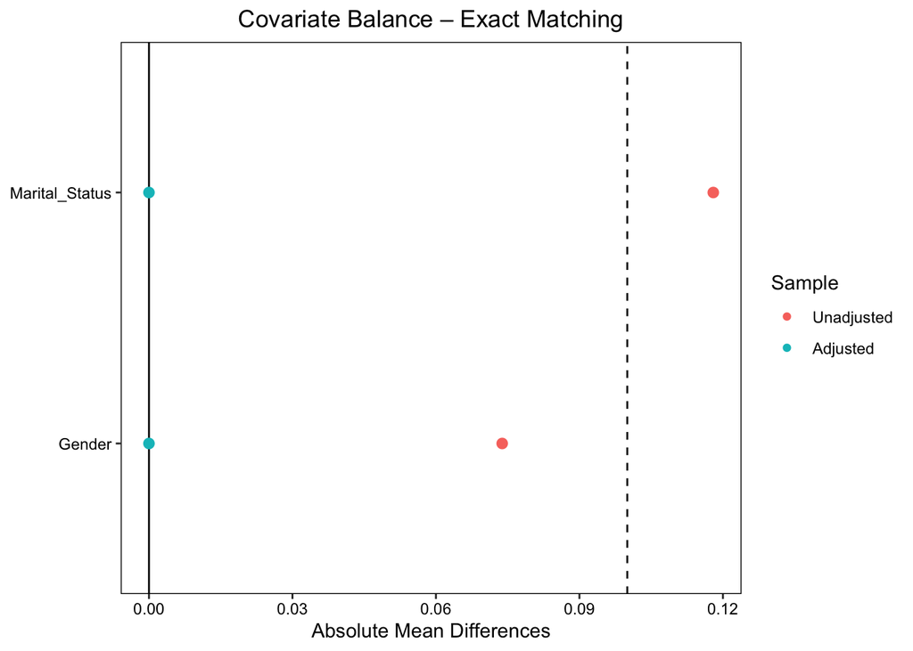

```r
bal_exact <- bal.tab(matches_exact, un = TRUE)
love.plot(bal_exact, stats="mean.diffs", abs=TRUE, thresholds=c(m=.1),
          var.order="unadjusted",
          title="Covariate Balance – Exact Matching")
```

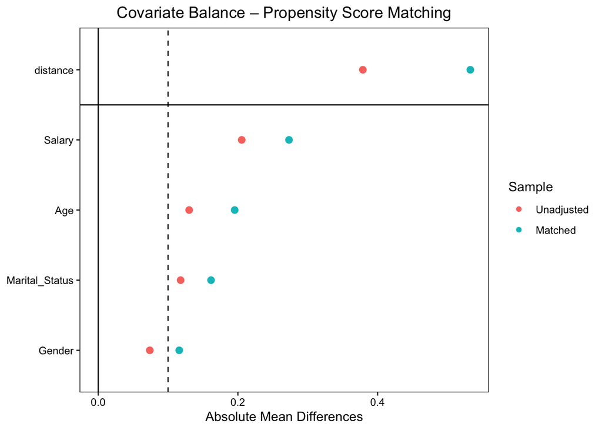

```r
bal_psm <- bal.tab(matches_psm, un = TRUE)
love.plot(
  bal_psm,
  stats = "mean.diffs",
  abs = TRUE,
  thresholds = c(m = .1),
  var.order = "unadjusted",
  title = "Covariate Balance – Propensity Score Matching",
  sample.names = c("Unadjusted", "Matched")
)
```

The covariate balance plot shows that after weighting, standardized mean differences for Age, Salary, Gender, and Marital Status are all extremely close to zero. In contrast, the unadjusted sample exhibits noticeable imbalance, especially for Salary and Age.

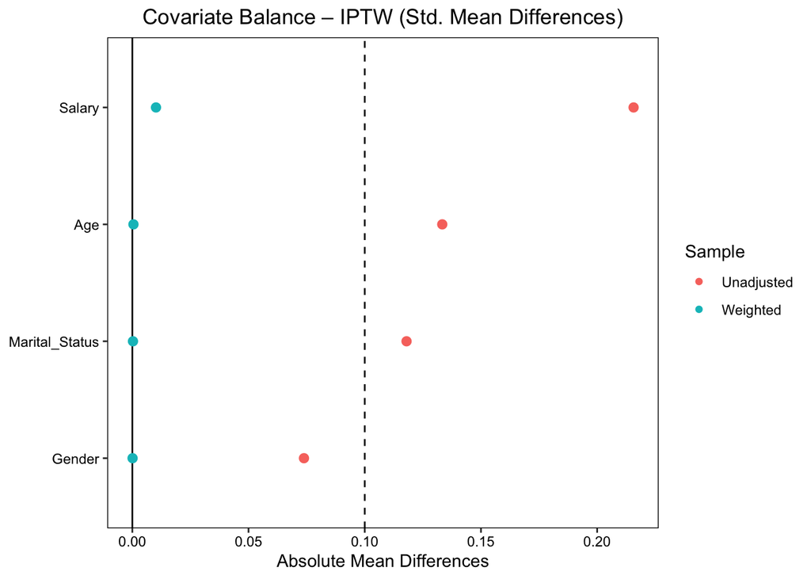

```r
love.plot(
  bal_iptw,
  stats = "mean.diffs",
  abs = TRUE,
  thresholds = c(m = .1),
  var.order = "unadjusted",
  title = "Covariate Balance – IPTW (Std. Mean Differences)",
  sample.names = c("Unadjusted", "Weighted")
)
```

The distribution of stabilized IPTW weights is centered near 1, with most weights concentrated below 1.5 and only a small right tail. This suggests that no observations receive excessively large influence and that the weighted estimation remains stable and well-behaved.

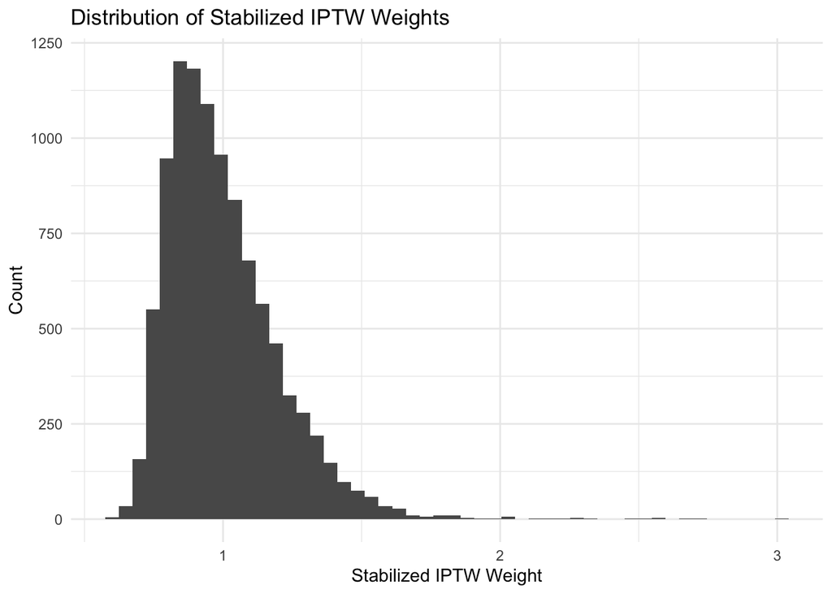

```r
ggplot(data, aes(x = iptw_weight)) +
  geom_histogram(bins = 50) +
  labs(
    title = "Distribution of Stabilized IPTW Weights",
    x = "Stabilized IPTW Weight",
    y = "Count"
  ) +
  theme_minimal()
```

```r
extract_result <- function(model, method_name) {
  robust_se <- vcovHC(model, type = "HC1")
  ct <- coeftest(model, vcov = robust_se)

  est <- ct["Membership", "Estimate"]
  se  <- ct["Membership", "Std. Error"]
  p   <- ct["Membership", "Pr(>|t|)"]

  p_formatted <- ifelse(p < 0.001, "< 0.001", sprintf("%.3f", p))

  tibble(
    Method = method_name,
    Estimate = round(est, 3),
    SE_HC1 = round(se, 3),
    CI_Lower = round(est - 1.96 * se, 3),
    CI_Upper = round(est + 1.96 * se, 3),
    p_value = p_formatted
  )
}

results_summary <- bind_rows(
  extract_result(model_exact, "Exact Matching"),
  extract_result(model_psm,   "Propensity Score Matching"),
  extract_result(model_iptw,  "IPTW")
)

print(results_summary)
```

```
# A tibble: 3 × 6
  Method                    Estimate SE_HC1 CI_Lower CI_Upper p_value
  <chr>                        <dbl>  <dbl>    <dbl>    <dbl> <chr>
1 Exact Matching               1205.   8.23    1189.    1221. < 0.001
2 Propensity Score Matching    1207.   8.52    1190.    1223. < 0.001
3 IPTW                         1204.   8.14    1188.    1220. < 0.001
```

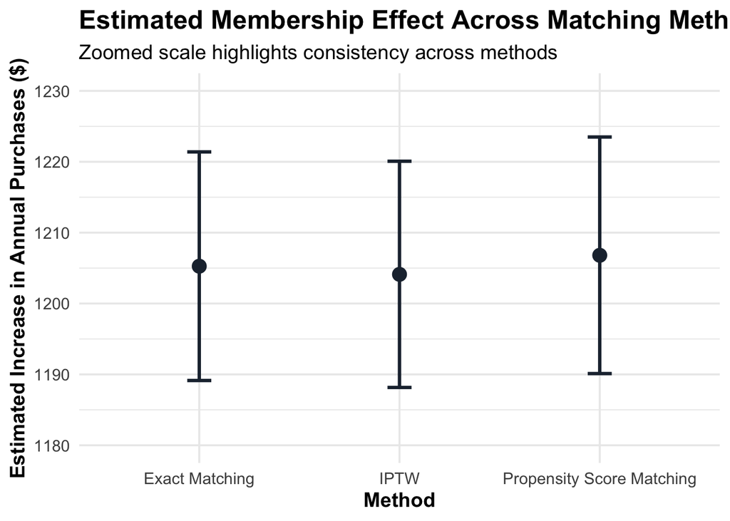

```r
ggplot(results_summary, aes(x = Method, y = Estimate)) +
  geom_point(size = 4, color = "#1f2d3d") +
  geom_errorbar(aes(ymin = CI_Lower, ymax = CI_Upper),
                width = 0.12, size = 1.1, color = "#1f2d3d") +
  geom_hline(yintercept = 0, linetype = "dashed", color = "red", size = 1) +

  coord_cartesian(ylim = c(1180, 1230)) +

  labs(
    title = "Estimated Membership Effect Across Matching Methods",
    subtitle = "Zoomed scale highlights consistency across methods",
    y = "Estimated Increase in Annual Purchases ($)",
    x = "Method"
  ) +
  theme_minimal(base_size = 14) +
  theme(
    plot.title = element_text(face = "bold", size = 18),
    axis.title = element_text(face = "bold")
  )
```

**Non technical Summary:** Across three different statistical methods, we find strong and consistent evidence that customers enrolled in the VIC loyalty program spend substantially more per year.

After accounting for differences in customer demographics and income: 1. Members spend about $1,200 more per year than comparable non-members 2. This result is stable regardless of the analytical approach used 3. The effect is statistically precise and highly reliable

**Business implications for Harris Teeter:** VIC membership represents a measurable economic asset per customer. With an estimated spending lift of roughly $1,200 per member per year, the program is not just a retention tool but a source of incremental revenue.

This figure helps anchor pricing and promotion decisions. Any discounts, rewards, or sign-up incentives that cost meaningfully less than the expected incremental spend can be justified on economic grounds. In other words, the estimated value per member provides an upper bound for how much Harris Teeter can afford to invest in acquiring or retaining a VIC customer while still generating net gain.

It also suggests that promotions tied to membership enrollment — rather than broad, untargeted discounts — are likely to be more efficient. Encouraging customers to join the program may create longer-term spending lift, rather than just shifting the timing of purchases.

Overall, the VIC program should be managed not just as a loyalty feature, but as a customer-level value driver, with pricing and promotional strategy aligned to the incremental revenue it appears to generate.